# BOM1 TASK 1: ESTIMATING POPULATION SIZE

Amy Nguyen

###Packages Installing and loading required packages.

```r
install.packages("dplyr")
install.packages("tibble")
```

```
Error in install.packages : Updating loaded packages
```

```r
install.packages("tidyverse")
install.packages("ggpubr")
install.packages("tibble")
```

###Introduciton The United States collects and analyzes demographic data from the U.S. population. The U.S. Census Bureau provides annual estimates of the population size of each U.S. state and region. Many important decisions are made using the estimated population dynamics, including the investments in new infrastructure, such as schools and hospitals; establishing new job training centers; opening or closing schools and senior centers; and adjusting the emergency services to the size and characteristics of the demographics of metropolitan and other areas, states, or the country as a whole. The census data and estimates are publicly available on the U.S. census website. Data analysts use a variety of tools to create models for predictions, including models of population dynamics of a state of a region. For this project, you will use R to create a linear regression model of the population dynamics of your state and predict the size of its population.

###Importing the Data For this project the data can be found from the U.S. Census Bureau at WWW.census.org. For our purposes I’ve decided to use the “City and Town Population Totals: 2010-2019” for Texas. This data can be found at https://www.census.gov/data/datasets/time-series/demo/popest/2010s-total-cities-and-towns.html#ds. My first step of this project was to import the data into a dataframe in R.

```r
population <- read.csv("https://www2.census.gov/programs-surveys/popest/datasets/2010-2019/cities/totals/sub-est2019_48.csv", stringsAsFactors = FALSE)
head(population)
```

|  | SUMLEV | STATE | COUNTY | PLACE | COUSUB | CONCIT | PRIMGEO_FLAG | FUNCSTAT | NAME | STNAME | CENSUS2010POP | ESTIMATESBASE2010 | POPESTIMATE2010 | POPESTIMATE2011 | POPESTIMATE2012 | POPESTIMATE2013 | POPESTIMATE2014 | POPESTIMATE2015 | POPESTIMATE2016 | POPESTIMATE2017 | POPESTIMATE2018 | POPESTIMATE2019 |
| --- | --- | --- | --- | --- | --- | --- | --- | --- | --- | --- | --- | --- | --- | --- | --- | --- | --- | --- | --- | --- | --- | --- |
| 1 | 40 | 48 | 0 | 0 | 0 | 0 | 0 | A | Texas | Texas | 25145561 | 25146091 | 25241971 | 25645629 | 26084481 | 26480266 | 26964333 | 27470056 | 27914410 | 28295273 | 28628666 | 28995881 |
| 2 | 162 | 48 | 0 | 100 | 0 | 0 | 0 | A | Abbott city | Texas | 356 | 361 | 362 | 362 | 361 | 355 | 354 | 354 | 356 | 361 | 365 | 369 |
| 3 | 162 | 48 | 0 | 160 | 0 | 0 | 0 | A | Abernathy city | Texas | 2805 | 2812 | 2818 | 2833 | 2822 | 2798 | 2738 | 2724 | 2741 | 2735 | 2711 | 2706 |
| 4 | 162 | 48 | 0 | 1000 | 0 | 0 | 0 | A | Abilene city | Texas | 117063 | 117514 | 117805 | 118762 | 119853 | 119797 | 120648 | 121707 | 121883 | 122186 | 122775 | 123420 |
| 5 | 162 | 48 | 0 | 1108 | 0 | 0 | 0 | A | Ackerly city | Texas | 220 | 220 | 220 | 219 | 219 | 225 | 228 | 230 | 229 | 228 | 229 | 232 |
| 6 | 162 | 48 | 0 | 1240 | 0 | 0 | 0 | A | Addison town | Texas | 13056 | 12537 | 12565 | 13259 | 14640 | 14871 | 14931 | 15013 | 14945 | 14924 | 15338 | 16263 |

### Cleaning and Prepping The Data

For this project a linear regression will be created using the total population estimate for each year from 2010 to 2019. Therefore, in order to simplify and improve the readability of the data we will be removing any unnecessary columns and/or rows.

```r
df <- subset(population, select = -c(SUMLEV, STATE, COUNTY, PLACE, COUSUB, CONCIT, PRIMGEO_FLAG, FUNCSTAT))
head(df)
```

|  | NAME | STNAME | CENSUS2010POP | ESTIMATESBASE2010 | POPESTIMATE2010 | POPESTIMATE2011 | POPESTIMATE2012 | POPESTIMATE2013 | POPESTIMATE2014 | POPESTIMATE2015 | POPESTIMATE2016 | POPESTIMATE2017 | POPESTIMATE2018 | POPESTIMATE2019 |
| --- | --- | --- | --- | --- | --- | --- | --- | --- | --- | --- | --- | --- | --- | --- |
| 1 | Texas | Texas | 25145561 | 25146091 | 25241971 | 25645629 | 26084481 | 26480266 | 26964333 | 27470056 | 27914410 | 28295273 | 28628666 | 28995881 |
| 2 | Abbott city | Texas | 356 | 361 | 362 | 362 | 361 | 355 | 354 | 354 | 356 | 361 | 365 | 369 |
| 3 | Abernathy city | Texas | 2805 | 2812 | 2818 | 2833 | 2822 | 2798 | 2738 | 2724 | 2741 | 2735 | 2711 | 2706 |
| 4 | Abilene city | Texas | 117063 | 117514 | 117805 | 118762 | 119853 | 119797 | 120648 | 121707 | 121883 | 122186 | 122775 | 123420 |
| 5 | Ackerly city | Texas | 220 | 220 | 220 | 219 | 219 | 225 | 228 | 230 | 229 | 228 | 229 | 232 |
| 6 | Addison town | Texas | 13056 | 12537 | 12565 | 13259 | 14640 | 14871 | 14931 | 15013 | 14945 | 14924 | 15338 | 16263 |

- The cleaned data has been put into a new data frame named “df”. Specifically, a subset of the original data without the columns SUMLEV, STATE, COUNTY, PLACE, COUSUB, CONCIT, PRIMGEO_FLAG, and FUNCSTAT has been put into a dataframe named “df”

Now that the data has each unnecessary column removed, it can be further manipulated. For the purpose of estimating the total population for the state of Texas we only need the information in the first row or the “State Total”. Thus, we can pull that data out using the head() function and put it into a new dataframe.

The issue now is that the X values and Y value are in the wrong spot. In order to build a linear regression model where the target is population and the predictor is time the rows and columns need to be reversed. Therefore, the next step is to transpose “total” and correct any other issues such as column names.

```r
library(dplyr)
total <- head(df, n=1)
total <- as.data.frame(t(total))
total <- tibble::rownames_to_column(total, "Year")
colnames(total)[2] <- "Population_Estimates"
head(total)
```

|  | Year | Population_Estimates |
| --- | --- | --- |
| 1 | NAME | Texas |
| 2 | STNAME | Texas |
| 3 | CENSUS2010POP | 25145561 |
| 4 | ESTIMATESBASE2010 | 25146091 |
| 5 | POPESTIMATE2010 | 25241971 |
| 6 | POPESTIMATE2011 | 25645629 |

```r
total <- total[-c(1,2,3,4),]
total$Year <-c(2010, 2011, 2012, 2013, 2014, 2015, 2016, 2017, 2018, 2019)

head(total)
```

|  | Year | Population_Estimates |
| --- | --- | --- |
| 5 | 2010 | 25241971 |
| 6 | 2011 | 25645629 |
| 7 | 2012 | 26084481 |
| 8 | 2013 | 26480266 |
| 9 | 2014 | 26964333 |
| 10 | 2015 | 27470056 |

The last thing to do is change the data types for the column “Population_Estimates”. Using the str() function it can be seen that "Population_Estimates is a character data type.

```r
str(total)
```

```
'data.frame':   10 obs. of  2 variables:
 $ Year                : num  2010 2011 2012 2013 2014 ...
 $ Population_Estimates: chr  "25241971" "25645629" "26084481" "26480266" ...
```

For the current scenario it is necessary to convert “Population_Estimates” to an integer data type.

```r
total$Population_Estimates <-as.integer(as.character(total$Population_Estimates))
str(total)
```

```
'data.frame':   10 obs. of  2 variables:
 $ Year                : num  2010 2011 2012 2013 2014 ...
 $ Population_Estimates: int  25241971 25645629 26084481 26480266 26964333 27470056 27914410 28295273 28628666 28995881
```

The data has now been cleaned and manipulated in order to easily create a linear regression with “Year” as the predictor or independent variable and “Population_Estimates” as the dependent variable.

### Creating a Linear Regression

In order to predict the future population size for the state of Texas a linear regression model named “lmPop” will be created using the lm() function.

```r
lmPop <-lm(Population_Estimates~Year, data = total)
lmPop
```

```
Call:
lm(formula = Population_Estimates ~ Year, data = total)

Coefficients:
(Intercept)         Year
 -833917553       427446
```

The linear regression equation for the data is Y = Year(X) + Intercept or Y = 427,446(X) + -833,917,553.

A graph of the data points and the linear regression line can be seen below:

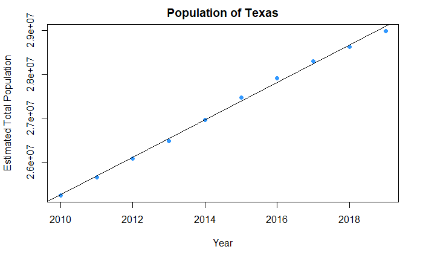

```r
plot(total$Year, total$Population_Estimates,
     main = "Population of Texas",
     xlab = "Year",
     ylab = "Estimated Total Population",
     pch = 19,
     col = "#3399FF")

abline(lmPop)
```

### Statisitcal Description of The Model Using summary()

```r
summary(lmPop)
```

```
Call:
lm(formula = Population_Estimates ~ Year, data = total)

Residuals:
   Min     1Q Median     3Q    Max
-99722 -37220 -12810  42411 101145

Coefficients:
              Estimate Std. Error t value Pr(>|t|)
(Intercept) -833917553   14823968  -56.26 1.11e-11 ***
Year            427446       7359   58.09 8.57e-12 ***
---
Signif. codes:  0 ‘***’ 0.001 ‘**’ 0.01 ‘*’ 0.05 ‘.’ 0.1 ‘ ’ 1

Residual standard error: 66840 on 8 degrees of freedom
Multiple R-squared:  0.9976,    Adjusted R-squared:  0.9973
F-statistic:  3374 on 1 and 8 DF,  p-value: 8.567e-12
```

### Predicting Future Population

In order to predict the future population for the state of Texas a data frame needs to be created with one column for the years to be predicted and another column to hold the future predicted values.

```r
future_df <- data.frame("Year" = 2020:2030, "Population_Estimates" = 0)
future_df
```

| Year | Population_Estimates |
| --- | --- |
| 2020 | 0 |
| 2021 | 0 |
| 2022 | 0 |
| 2023 | 0 |
| 2024 | 0 |
| 2025 | 0 |
| 2026 | 0 |
| 2027 | 0 |
| 2028 | 0 |
| 2029 | 0 |

[output cut: 1 more lines]

```r
NA
```

Now that the data frame holding future year values has been created it is now possible to use the predict() function to predict the population for future years.

```r
predictions <- predict(lmPop, newdata = future_df)

future_df$Population_Estimates <- predictions
future_df
```

| Year | Population_Estimates |
| --- | --- |
| 2020 | 29523049 |
| 2021 | 29950495 |
| 2022 | 30377940 |
| 2023 | 30805386 |
| 2024 | 31232832 |
| 2025 | 31660278 |
| 2026 | 32087724 |
| 2027 | 32515170 |
| 2028 | 32942615 |
| 2029 | 33370061 |

[output cut: 1 more lines]

```r
NA
```

Looking at the table above we can see that the total population of Texas in 2025 is predicted to be 31,660,278.